# Atividade 2 - Checkpoint 1

Dandara Sousa

4 de junho de 2017

Para esta análise foi utilizada um conjunto de dados de séries avaliadas no IMDB. Nele está contido informações de nome da série, nome e número do episódio, a url onde está hospedado o episódio no IMDB, a nota do usuário, o número de votos e a quantidade de votos que cada uma das notas receberam.

```
##  [1] "series_name" "Episode"     "series_ep"   "season"      "season_ep"
##  [6] "url"         "UserRating"  "UserVotes"   "r1"          "r2"
## [11] "r3"          "r4"          "r5"          "r6"          "r7"
## [16] "r8"          "r9"          "r10"
```

Nesta análise nem todas as informações de uma série serão utilizadas. O foco será principalmente nas avaliações com base em votações dos usuários do IMDB feitas para séries da produtora CW.

### Análise de séries CW em exibição

As atuais séries da CW e suas temporadas são:

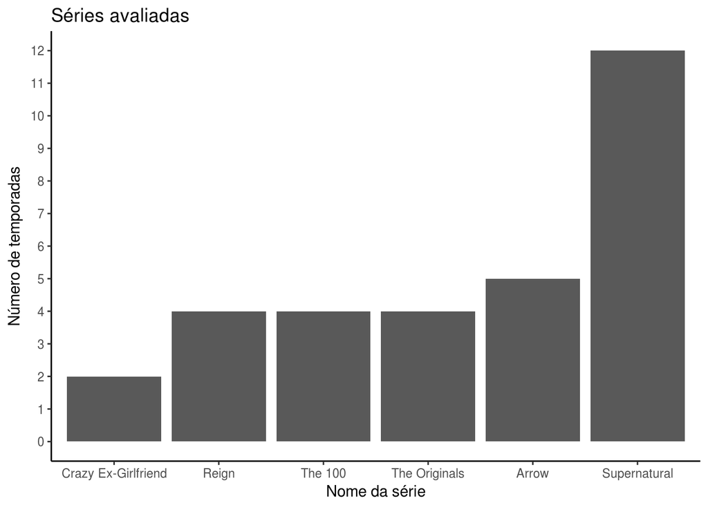

**Pergunta 1. Qual das séries que você escolheu é mais bem avaliada no IMDB? A diferença é grande? Pequena?**

[interactive chart not shown]

A partir do bloxplot com a mediana de cada série pode-se observar que, de forma geral,The Originals é a série mais bem avaliada no IMDB. Porém a maior nota foi dada para um episódio em Arrow. A segunda e terceira série mais bem avaliada respectivamente são Supernatural e Arrow.

**Pergunta 2. As séries antigas são mais bem avaliadas que as novas?**

Considerando a série mais antiga como a que possui mais temporada e a mais nova como a que possui menos, Supernatural é a série mais antiga em exibição na CW enquanto Crazy Ex-Girlfriend é a mais nova. A partir do boxplot mostrado acima (*Avaliações de Série*) é possível observar que a avaliação de Supernatural é maior que a série mais jovem. Isso pode indicar que os fãs da série são tão assíduos que a produtora não vê a necessidade de cancelar a série.

**Pergunta 3. As notas crescem de acordo com a temporada?**

[interactive chart not shown]

De forma geral é possível perceber que apenas Supernatural e The Originals caíram de nota na última temporada. Supernatural teve sua nota quase igualada à de sua décima temporada e The Originals com a de sua segunda. Podemos considerar então a temporada antecedente da última como picos em avaliações. E a partir daí dizer que não há um padrão de crescimento mas as séries que ainda estão sendo produzidas não possuem sequências de quedas de avaliação significante.